# Migrating COM API calls to Python

##### Snapshot Requests Tip 1

Some fundamental fields will give multiple rows for a given day - for example if we request ratings sources - there could be more than one per date eg if there are 5 ratings agencies providing a rating - this is not usual for a time series history - or perhaps it is very different say than non-expandable single point timeseries. In this example as we have multiple RICS whose ratings dates may not overlap ie be on the same row `<NA>` artifacts are added to deliver the dataframe

```python
df2 = rd.get_history(
    universe=['BARC.L', 'TRI.N','TSLA.O'],
    fields=['TR.IR.RatingSourceDescription', 'TR.IR.RatingSourceType',
            'TR.IR.Rating','TR.IR.Rating.date'],
    interval="1Y",
    start="2015-01-25",
    end="2022-02-01")

df2
```

| Date | BARC.L Rating Source Description | BARC.L Rating Source Type | BARC.L Issuer Rating | BARC.L Date | TRI.N Rating Source Description | TRI.N Rating Source Type | TRI.N Issuer Rating | TRI.N Date | TSLA.O Rating Source Description | TSLA.O Rating Source Type | TSLA.O Issuer Rating | TSLA.O Date |
| --- | --- | --- | --- | --- | --- | --- | --- | --- | --- | --- | --- | --- |
| 2015-07-16 | <NA> | <NA> | <NA> | NaT | S&P Senior Unsecured | SSU | NR | 2015-07-16 | <NA> | <NA> | <NA> | NaT |
| 2015-11-19 | Fitch Senior Unsecured | FSU | A | 2015-11-19 | <NA> | <NA> | <NA> | NaT | <NA> | <NA> | <NA> | NaT |
| 2015-11-19 | Fitch Short-term Debt Rating | FDT | F1 | 2015-11-19 | <NA> | <NA> | <NA> | NaT | <NA> | <NA> | <NA> | NaT |
| 2016-08-16 | <NA> | <NA> | <NA> | NaT | Fitch Senior Unsecured | FSU | WD | 2016-08-16 | <NA> | <NA> | <NA> | NaT |
| 2016-12-12 | Moody's Long-term Issuer Rating | MIS | Baa2 | 2016-12-12 | <NA> | <NA> | <NA> | NaT | <NA> | <NA> | <NA> | NaT |
| 2016-12-12 | Moody's Long-term Senior Unsecured MTN Rating | MMU | (P)Baa2 | 2016-12-12 | <NA> | <NA> | <NA> | NaT | <NA> | <NA> | <NA> | NaT |
| 2016-12-12 | Moody's Senior Unsecured | MSU | Baa2 | 2016-12-12 | <NA> | <NA> | <NA> | NaT | <NA> | <NA> | <NA> | NaT |
| 2017-04-27 | <NA> | <NA> | <NA> | NaT | S&P Short-term Issuer Credit Rating | SIS | A-2 | 2017-04-27 | <NA> | <NA> | <NA> | NaT |
| 2017-08-07 | <NA> | <NA> | <NA> | NaT | <NA> | <NA> | <NA> | NaT | Moody's Speculative Grade Liquidity | MSL | SGL-3 | 2017-08-07 |
| 2017-08-07 | <NA> | <NA> | <NA> | NaT | <NA> | <NA> | <NA> | NaT | Moody's Probability of Default Rating | MPD | B2-PD | 2017-08-07 |
| 2017-08-07 | <NA> | <NA> | <NA> | NaT | <NA> | <NA> | <NA> | NaT | Moody's Corporate Family Rating | MCF | B2 | 2017-08-07 |
| 2017-10-06 | S&P Long-term Senior Unsecured MTN Rating | SMU | BBB | 2017-10-06 | <NA> | <NA> | <NA> | NaT | <NA> | <NA> | <NA> | NaT |
| 2018-08-15 | <NA> | <NA> | <NA> | NaT | <NA> | <NA> | <NA> | NaT | Egan-Jones Senior Unsecured | EJU | CC | 2018-08-15 |
| 2018-10-04 | <NA> | <NA> | <NA> | NaT | S&P Long-term Issuer Rating | SPI | BBB | 2018-10-04 | <NA> | <NA> | <NA> | NaT |
| 2018-10-04 | <NA> | <NA> | <NA> | NaT | S&P Senior Unsecured | SSU | BBB | 2018-10-04 | <NA> | <NA> | <NA> | NaT |
| 2018-12-28 | Egan-Jones Commercial Paper | EJC | A1 | 2018-12-28 | <NA> | <NA> | <NA> | NaT | <NA> | <NA> | <NA> | NaT |
| 2019-10-25 | <NA> | <NA> | <NA> | NaT | <NA> | <NA> | <NA> | NaT | Egan-Jones Senior Unsecured | EJU | CCC | 2019-10-25 |
| 2019-11-27 | R&I Long-term Issuer Rating | RII | A- | 2019-11-27 | <NA> | <NA> | <NA> | NaT | <NA> | <NA> | <NA> | NaT |
| 2019-12-02 | <NA> | <NA> | <NA> | NaT | Egan-Jones Senior Unsecured | EJU | BBB- | 2019-12-02 | <NA> | <NA> | <NA> | NaT |
| 2020-05-11 | <NA> | <NA> | <NA> | NaT | Moody's Senior Unsecured | MSU | Baa2 | 2020-05-11 | <NA> | <NA> | <NA> | NaT |
| 2020-11-18 | R&I Long-term Issuer Rating | RII | A- | 2020-11-18 | <NA> | <NA> | <NA> | NaT | <NA> | <NA> | <NA> | NaT |
| 2020-12-17 | <NA> | <NA> | <NA> | NaT | <NA> | <NA> | <NA> | NaT | S&P Long-term Issuer Rating | SPI | BB | 2020-12-17 |
| 2020-12-17 | <NA> | <NA> | <NA> | NaT | <NA> | <NA> | <NA> | NaT | S&P Senior Unsecured | SSU | BB | 2020-12-17 |
| 2021-10-22 | <NA> | <NA> | <NA> | NaT | <NA> | <NA> | <NA> | NaT | S&P Long-term Issuer Rating | SPI | BB+ | 2021-10-22 |
| 2021-10-22 | <NA> | <NA> | <NA> | NaT | <NA> | <NA> | <NA> | NaT | S&P Senior Unsecured | SSU | BB+ | 2021-10-22 |
| 2021-11-26 | R&I Long-term Issuer Rating | RII | A | 2021-11-26 | <NA> | <NA> | <NA> | NaT | <NA> | <NA> | <NA> | NaT |

##### Snapshot Requests Tip 2

Again this same multi-row exanding timeseries history - here in the case of broker recommendations - is another example - with lots of `<NA>` artifacts added.

```python
df2 = rd.get_history(
    universe=['BARC.L', 'TRI.N', 'TSLA.O'],
    fields=['TR.RecEstValue', 'TR.TPEstValue', 'TR.EPSEstValue'],
    interval="1M",
    start="2020-01-25",
    end="2022-02-01")
df2
```

| Date | BARC.L Standard Rec (1-5) - Broker Estimate | BARC.L Target Price - Broker Estimate | BARC.L Earnings Per Share - Broker Estimate | TRI.N Standard Rec (1-5) - Broker Estimate | TRI.N Target Price - Broker Estimate | TRI.N Earnings Per Share - Broker Estimate | TSLA.O Standard Rec (1-5) - Broker Estimate | TSLA.O Target Price - Broker Estimate | TSLA.O Earnings Per Share - Broker Estimate |
| --- | --- | --- | --- | --- | --- | --- | --- | --- | --- |
| 2013-10-02 00:00:00 | 2 | <NA> | <NA> | <NA> | <NA> | <NA> | <NA> | <NA> | <NA> |
| 2013-10-02 00:00:00 | 2 | <NA> | <NA> | <NA> | <NA> | <NA> | <NA> | <NA> | <NA> |
| 2015-02-12 00:00:00 | <NA> | <NA> | <NA> | <NA> | <NA> | <NA> | 4 | <NA> | <NA> |
| 2015-02-12 00:00:00 | <NA> | <NA> | <NA> | <NA> | <NA> | <NA> | 4 | <NA> | <NA> |
| 2015-02-12 00:00:00 | <NA> | <NA> | <NA> | <NA> | <NA> | <NA> | 4 | <NA> | <NA> |
| ... | ... | ... | ... | ... | ... | ... | ... | ... | ... |
| 2022-01-31 00:00:00 | <NA> | <NA> | <NA> | <NA> | <NA> | <NA> | 2 | <NA> | <NA> |
| 2022-01-31 04:00:00 | <NA> | <NA> | <NA> | <NA> | <NA> | <NA> | <NA> | 244.99974 | <NA> |
| 2022-01-31 07:27:00 | <NA> | 248.3 | <NA> | <NA> | <NA> | <NA> | <NA> | <NA> | <NA> |
| 2022-01-31 21:05:00 | <NA> | <NA> | <NA> | <NA> | <NA> | <NA> | <NA> | 326.66633 | 4.28333 |
| 2022-01-31 23:00:00 | <NA> | <NA> | <NA> | <NA> | <NA> | <NA> | <NA> | <NA> | 4.84999 |

4050 rows × 9 columns

## DEX2

### What does this do?

The DEX2 interface provided a broad range of content and functionality such Fundamental and Reference as well as timeseries histories of such fields. The DEX2 interface also provided interday timeseries histories for both realtime and non-realtime data. In addition you could use it for symbology conversion.

### DEX2 ID to RIC (Symbology Conversion)

As shown in [Tutorial 6 - Data Engine - Dex2](https://developers.refinitiv.com/en/api-catalog/eikon/com-apis-for-use-in-microsoft-office/tutorials#tutorial-6-data-engine-dex-2)'s [Excel Workbook](https://developers.refinitiv.com/content/dam/devportal/api-families/eikon/com-apis-for-use-in-microsoft-office/tutorials/dex2.zip), we can convert symbols using the COM API.

#### VBA

After setting `MyDex2Mgr = CreateReutersObject("Dex2.Dex2Mgr")`, for ISINs, we can then go ahead with

> ```
> ' Must call Initialise() at once
> m_cookie = MyDex2Mgr.Initialize()
> ' We can then create an RData object
> Set myRData1 = MyDex2Mgr.CreateRData(m_cookie)
> ```

For SEDOL, we can use:

> ```
> ' Must call Initialise() at once
> m_cookie = MyDex2Mgr.Initialize()
> ' We can then create an RData object
> Set myRData2 = MyDex2Mgr.CreateRData(m_cookie)
> ```

#### Python

Symbology conversions in python are a lot more powerful than in Excel using the COM API. The extent of the use-cases for symbology conversions are best explained in our [GitHub Repository](https://github.com/Refinitiv-API-Samples/Example.DataLibrary.Python/blob/main/Examples/2-Content/2.05-Symbology/EX-2.05.01-Symbology.ipynb), but for the sake of completeness, you can see an example use in the 2 cells directly below:

```python
# # Get generic table of many symbols for 4 companies of choice:
response = rd.content.symbol_conversion.Definition(symbols=["MSFT.O", "AAPL.O", "GOOG.O", "IBM.N"]).get_data()
response.data.df
```

|  | DocumentTitle | RIC | IssueISIN | CUSIP | SEDOL | TickerSymbol | IssuerOAPermID |
| --- | --- | --- | --- | --- | --- | --- | --- |
| MSFT.O | Microsoft Corp, Ordinary Share, NASDAQ Global ... | MSFT.O | US5949181045 | 594918104 | <NA> | MSFT | 4295907168 |
| AAPL.O | Apple Inc, Ordinary Share, NASDAQ Global Selec... | AAPL.O | US0378331005 | 037833100 | <NA> | AAPL | 4295905573 |
| GOOG.O | Alphabet Inc, Ordinary Share, Class C, NASDAQ ... | GOOG.O | US02079K1079 | 02079K107 | <NA> | GOOG | 5030853586 |
| IBM.N | International Business Machines Corp, Ordinary... | IBM.N | US4592001014 | 459200101 | 2005973 | IBM | 4295904307 |

```python
# # Convert specific symbols:
response = rd.content.symbol_conversion.Definition(
    symbols=["US5949181045", "US02079K1079"],
    from_symbol_type=rd.content.symbol_conversion.SymbolTypes.ISIN,  # Symbol types: RIC => RIC; ISIN => IssueISIN; CUSIP => CUSIP; SEDOL => SEDOL; TICKER_SYMBOL => TickerSymbol; OA_PERM_ID => IssuerOAPermID; LIPPER_ID => FundClassLipperID
    to_symbol_types=[rd.content.symbol_conversion.SymbolTypes.RIC,
                     rd.content.symbol_conversion.SymbolTypes.OA_PERM_ID],
).get_data()

response.data.df
```

|  | DocumentTitle | RIC | IssuerOAPermID |
| --- | --- | --- | --- |
| US5949181045 | Microsoft Corp, Ordinary Share, NASDAQ Global ... | MSFT.O | 4295907168 |
| US02079K1079 | Alphabet Inc, Ordinary Share, Class C, NASDAQ ... | GOOG.O | 5030853586 |

### DEX2 RData Equity Data

As best exemplified in [Tutorial 6 - Data Engine - Dex2](https://developers.refinitiv.com/en/api-catalog/eikon/com-apis-for-use-in-microsoft-office/tutorials#tutorial-6-data-engine-dex-2)'s [Excel Workbook](https://developers.refinitiv.com/content/dam/devportal/api-families/eikon/com-apis-for-use-in-microsoft-office/tutorials/dex2.zip), the DEX2 RData Equity Data allows us to access historical [Market Capital](https://www.investopedia.com/terms/m/marketcapitalization.asp):

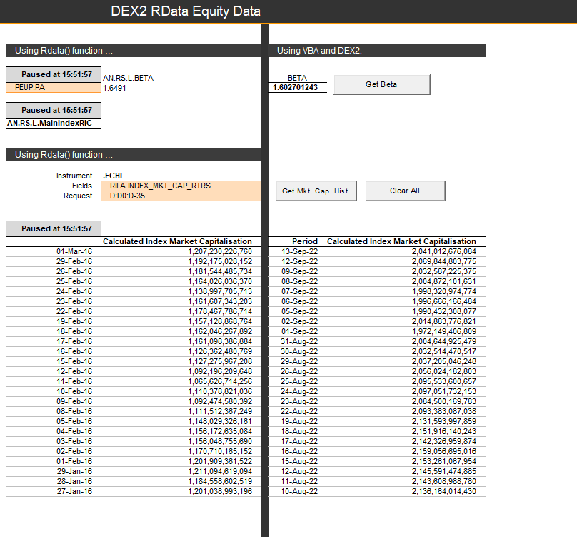

#### VBA

DEX2 replicates RData() and TR() functions for real time data retrieval in Eikon for Excel / Eikon - Microsoft Office. The DEX2 methods differ slightly in the initialisation and use of the Dex2Mgr object depending upon whether RData() or the TR() function is being replicated. The examples below explain this. The TR() function can be used to retrieve data from ADC (the Analytics Data Cloud) and this is contained in Tutorial 11 - Dex2 TR function Analytics Data Cloud ADC data here.

NOTE - Eikon for Excel or Eikon - Microsoft Office should be logged in otherwise the sample VBA code will generate an error "ERROR #360c - AdxRtx : No connection to the platform".

##### Prerequisites

1. Open a new single sheet Excel workbook. Save As with an appropriate name (e.g. DEX2.xls or DEX2.xlsm in Office 2007 or higher).
2. Go to the VBE (Visual Basic Editor), ensure the Project Explorer is visible and select the project for the workbook above. \<ALT>\<F11> or Tools, Macro, Visual Basic Editor in Excel 2003 or Developer, Visual Basic in Excel 2007 and above, View, Project Explorer If the Developer header is not visible in Excel 2007 and above, go to the Excel Office Button, select Excel Options (lower right), Popular, and check the 'Show Developer tab in the Ribbon' box.
3. In the VBE, click on File, Import File and import PLVbaApis.bas. The .bas location is C:\Program Files (x86)\Thomson Reuters\Eikon\Z\Bin (Z may be X or Y, depending on the last Eikon update). The .bas is loaded as a new VB project module, PLVbaApis.
4. In the PLVbaAPis module, comment out the sections which aren't required. As this example is dealing with DEX2, part of the library DEX2Lib, the DEX2 section can remain uncommented.
5. In the VBE, go Tools, References and ensure that the DEX2 Library is checked. If it is not in the list the library is called DEX2.dll and its location for Eikon 4 is;

   "C:\Program Files (x86)\Thomson Reuters\Eikon\Z\Bin" (Z may be X or Y, depending on the last Eikon update).

   Note that for the latest versions of Eikon the default path is;

   "C:\Program Files (x86)\Thomson Reuters\Eikon\Z\Bin\Apps\TR.OFFICE.CORE\0.0.0.0\Bin" (Z may be X or Y, depending on the last Eikon update).

##### DEX2

1. Create an instance of an DEX2Mgr object using the PLVbaApis function CreateDex2Mgr().

   Set myDEX2Mgr = CreateDex2Mgr()
2. To replicate RData(), create the Dex2Mgr object (myDex2Mgr) and initialise it. Use the return value from the initialisation to create an instance of the Dex2Lib.RData Class (myDex2RData) using the CreateRData method.
3. Now go ahead with `cmdMktCapHist_Click` creation:

#### Python

Couldn't be easier in Python:

```python
MarketCapDf = rd.get_history(
    universe=['VOD.L','BARC.L'],
    fields=['TR.CompanyMarketCapitalization'],
    interval="1D", # The consolidation interval. Supported intervals are: tick, tas, taq, minute, 1min, 5min, 10min, 30min, 60min, hourly, 1h, daily, 1d, 1D, 7D, 7d, weekly, 1W, monthly, 1M, quarterly, 3M, 6M, yearly, 1Y.
    start="2022-08-10",
    end="2022-09-13")
MarketCapDf
```

| Company Market Capitalization Date | VOD.L | BARC.L |
| --- | --- | --- |
| 2022-08-10 | 33802223010.1754 | 27530345491.2761 |
| 2022-08-11 | 33794859479.455799 | 27383302388.1096 |
| 2022-08-12 | 33887838289.451801 | 27786941607.566399 |
| 2022-08-15 | 33760332255.312 | 27758457269.677299 |
| 2022-08-16 | 34330055002.498199 | 27582105369.2075 |
| 2022-08-17 | 33921476881.010399 | 27285640404.213501 |
| 2022-08-18 | 33852812314.98 | 27254991056.654099 |
| 2022-08-19 | 33895552270.749599 | 26715133223.987099 |
| 2022-08-22 | 33370390822.183201 | 26340483067.0546 |
| 2022-08-23 | 32667366225.191601 | 26405224616.597 |
| 2022-08-24 | 32354167975.459202 | 26228825773.528999 |
| 2022-08-25 | 32424995730.497601 | 26460530529.603699 |
| 2022-08-26 | 32006294522.462399 | 26111834110.002102 |
| 2022-08-30 | 32177306259.669998 | 26513969180.666 |
| 2022-08-31 | 32173301195.822399 | 26465908012.175499 |
| 2022-09-01 | 31183087960.863998 | 25952476544.476002 |
| 2022-09-02 | 31637611471.132801 | 27098995077.109699 |
| 2022-09-05 | 31214614841.013 | 26740328947.705502 |
| 2022-09-06 | 31441185544.491199 | 26946735317.659801 |
| 2022-09-07 | 30607791334.971199 | 26329051688.2561 |
| 2022-09-08 | 29961315459.556 | 26660365893.3447 |
| 2022-09-09 | 30115778305.900799 | 27059086414.891899 |
| 2022-09-12 | 30687668213.294399 | 27864039078.710098 |
| 2022-09-13 | 30275827984.525002 | 27526300174.723099 |

### DEX2 Time Series

DEX2 returns reference and fundamental data for instruments. Data includes identifiers such as ISIN and Cusip codes for an instrument, market capitalisation history, business sector information, ratings information and time series data. This was best exemplified in [Tutorial 6 - Data Engine - Dex2](https://developers.refinitiv.com/en/api-catalog/eikon/com-apis-for-use-in-microsoft-office/tutorials#tutorial-6-data-engine-dex-2)'s [Excel Workbook](https://developers.refinitiv.com/content/dam/devportal/api-families/eikon/com-apis-for-use-in-microsoft-office/tutorials/dex2.zip):

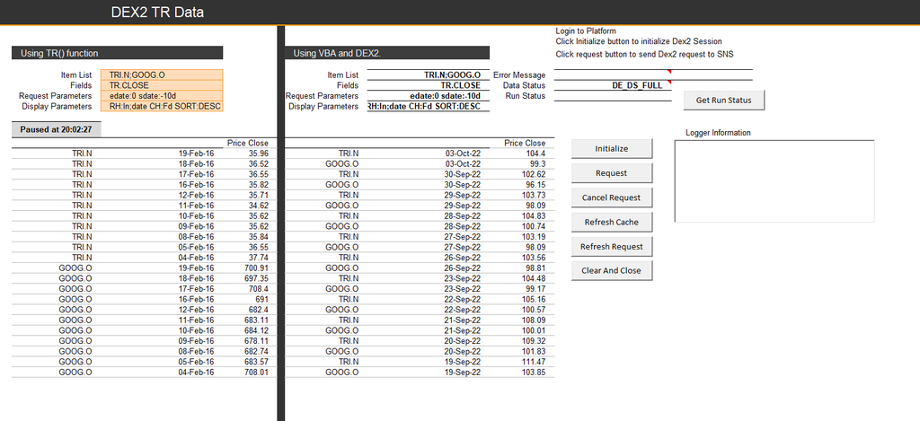

#### VBA

You'd have to Initialize Dex2 session under the sub `cmdInitialize_Click()`:

#### Python

In Python, things are a little simpler:

```python
DEX2Df = rd.get_history(
    universe=['VOD.L', 'BARC.L', 'TRI.N'],
    fields=['TR.TotalReturn', 'TR.PRICECLOSE'],
    interval="1D",
    start="2021-10-01",
    end="2021-10-11")

DEX2Df
```

| Date | VOD.L Total Return | VOD.L Price Close | BARC.L Total Return | BARC.L Price Close | TRI.N Total Return | TRI.N Price Close |
| --- | --- | --- | --- | --- | --- | --- |
| 2021-10-01 | -0.970874 | 112.2 | -0.907173 | 187.88 | -0.289645 | 110.16 |
| 2021-10-04 | 1.4082 | 113.78 | -0.319353 | 187.28 | -0.67175 | 109.42 |
| 2021-10-05 | 0.773422 | 114.66 | 3.908586 | 194.6 | 0.923049 | 110.43 |
| 2021-10-06 | -2.651317 | 111.62 | -1.387461 | 191.9 | 1.213438 | 111.77 |
| 2021-10-07 | 0.734635 | 112.44 | 0.958833 | 193.74 | 1.673079 | 113.64 |
| 2021-10-08 | -0.302383 | 112.1 | 0.732941 | 195.16 | 0.228793 | 113.9 |
| 2021-10-11 | -0.303301 | 111.76 | 1.291248 | 197.68 | 0.412643 | 114.37 |

### DEX2 RData Treasury Data

This functionality was best shown in [Tutorial 6 - DEX2 Treasury](https://developers.refinitiv.com/en/api-catalog/eikon/com-apis-for-use-in-microsoft-office/tutorials#tutorial-6-data-engine-dex-2) where Treasury Ratings and their Source Descriptions were discoverable:

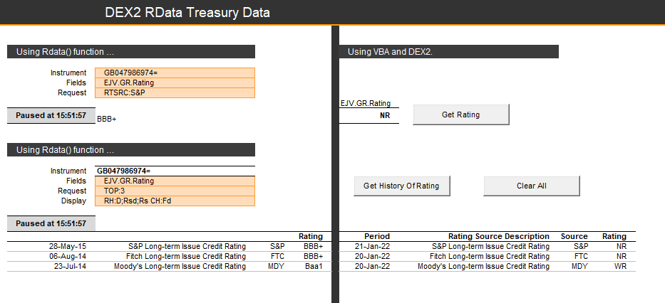

#### VBA

> ```
> Private Sub cmdClearAll_Click()
>     ActiveCell.Select
>
>     Range("G10").Value = ""
>     Range("G21:J100").Value = ""
>
>     If Not myRData1 Is Nothing Then Set myRData1 = Nothing
>     If Not myRData2 Is Nothing Then Set myRData2 = Nothing
>     If Not MyDex2Mgr Is Nothing Then Set MyDex2Mgr = Nothing
> End Sub
> ```

#### Python

Things are much simpler in Python:

```python
rating = rd.get_history(
    universe=['GB137283921='],
    fields=['TR.IR.RatingSourceDescription', 'TR.IR.RatingSourceType',
            'TR.IR.Rating'],
    interval="1Y",
    start="2015-01-25",
    end="2023-02-01")
rating
```

| GB137283921= Date | Rating Source Description | Rating Source Type | Issuer Rating |
| --- | --- | --- | --- |
| 2015-12-17 | Egan-Jones Commercial Paper | EJC | A1 |
| 2015-12-17 | Egan-Jones Senior Unsecured | EJU | BBB+ |
| 2016-07-06 | Egan-Jones Senior Unsecured | EJU | BBB |
| 2018-10-04 | Fitch Subordinated | FBD | BBB- |
| 2019-11-26 | Egan-Jones Senior Unsecured | EJU | BBB- |
| 2021-07-29 | Fitch Commercial Paper | FCP | F2 |
| 2022-11-25 | Egan-Jones Commercial Paper | EJC | A1 |

### DEX2 Fundamental and Reference

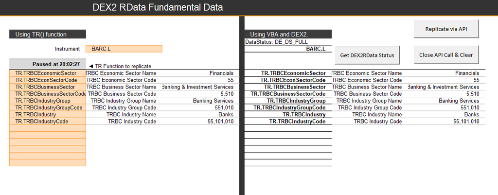

Time Series data as the name suggests changes with time. Reference data, on the other hand, does not primarily change with time; when it does, it usually accounts for a structural change in the instrument at play (e.g.: a company changes from banking to tech operation industries or is acquired and changes name etc). Fundamental data is released temporally say quarterly or half-yearly or annually and is usually looked at across time eg Revenue or Sales. DEX2 provides access to all of our TR fields - which allow you to specify begin dates and end dates amongst other parameters. Access to these is unchanged in our new APIs - only its a lot simpler.

#### VBA

In VBA, after creating '`Private MyDex2Mgr As Dex2Lib.Dex2Mgr`':

> ```
> Private MyDex2Mgr As Dex2Lib.Dex2Mgr
> Private MyDex2MgrADC As Dex2Lib.IDex2Mgr2
> Private MyDex2Cookie As Long
> ' Private variable that holds the Dex2 RData, able to obtain TR fields.
> Private WithEvents MyDex2RData As Dex2Lib.RData
> ```

to complete the Tutorial 6 example, one could go through the following to collect DEX2 Fundamental and Reference data:

> ```
>     ' Now create the Dex2 and IDex2 objects.
>     Set MyDex2Mgr = CreateDex2Mgr()
>     Set MyDex2MgrADC = MyDex2Mgr
>
>     ' Initialise using the DE_MC_ADC_POWERLINK enumeration
>     MyDex2Cookie = MyDex2MgrADC.Initialize(DE_MC_ADC_POWERLINK)
>     ' And create an RData object.
>     Set MyDex2RData = MyDex2Mgr.CreateRData(MyDex2Cookie)
>
>     With MyDex2RData
>         .InstrumentIDList = Range("G6").Value ' Or for multiple isntruments "TRI.N;MSFT.O;GOOG.O"
>         .FieldList = strInstrList '  Or single field "TR.CLOSE"
>         .RequestParam = "" ' Or of the form "edate:-20d sdate:-9d"
>         .DisplayParam = "CH:Fd" ' Or of the form "RH:In CH:Fd"
>
>         '' OR can use .SetParameter
>         '.SetParameter Range("G6").Value, strInstrList, "", "CH:Fd"
>
>         ' Send the query without using cache
>         .Subscribe False  ' Or use cache by default - myDex2RData.Subscribe
>
>         ' When the data is returned, the myDex2RData_OnUpdate event and Sub are 'fired'.
> ```

#### Python

Fundamental data was covered above under 'RData Fundamentals'; such data can be found in Python with [RD](https://developers.refinitiv.com/en/api-catalog/refinitiv-data-platform/refinitiv-data-library-for-python) (and `rd.get_data`, `rd.get_history` or `rd.content.fundamental_and_reference.Definition`) or [EDAPI](https://developers.refinitiv.com/en/api-catalog/eikon/eikon-data-api).

#### Fundamental and Reference Timeseries

##### VBA

DEX2 Fundamental and Reference Timeseries data could be fetched similarly to simple time series data:

Start with

> ```
> ' Private Variable that holds the instance of the Dex2 manager singleton
> Private MyDex2Mgr As Dex2Lib.Dex2Mgr
> Private MyDex2MgrADC As Dex2Lib.IDex2Mgr2
> ```

Then initialise clicks:

> ```
>     ' Instantiate the Dex2 manager
>     Set MyDex2Mgr = CreateDex2Mgr()
>     Set MyDex2MgrADC = MyDex2Mgr
>     ' Instantiate the RSearch logger
>     Set MyDex2Logger = New CLogger
>
>     ' Initialize Dex2 session
>     MyDex2Cookie = MyDex2MgrADC.Initialize(DE_MC_ADC_POWERLINK, MyDex2Logger)
>
>     ' We can choose to display error code
>     MyDex2Mgr.SetErrorHandling MyDex2Cookie, DE_EH_ERROR_CODES
>     ' Or display error description
>     ' MyDex2Mgr.SetErrorHandling MyDex2Cookie, DE_EH_STRING
>
>     ' Create a Dex2 query using the session cookie
>     Set MyDex2RData = MyDex2Mgr.CreateRData(MyDex2Cookie)
>
>     ' Create a Dex2 query manager using the session cookie
>     Set MyDex2RDataMgr = MyDex2Mgr.CreateRDataMgr(MyDex2Cookie)
> ```

Then, after some error & event handling:

> ```
>     ' Set input values
>             MyDex2RData.SetParameter _
>                 Range("Dex2Item").Value, _
>                 Range("Dex2Fields").Value, _
>                 Range("Dex2RequestParameters").Value, _
>                 Range("Dex2DisplayParameters").Value
>                 ' Or using the following individual properties
>                 ' MyDex2RData.InstrumentIDList = Range("Dex2Item").Value
>                 ' MyDex2RData.FieldList = Range("Dex2Fields").Value
>                 ' MyDex2RData.requestParam = Range("Dex2RequestParameters").Value
>                 ' MyDex2RData.displayParam = Range("Dex2DisplayParameters").Value
> ```

Before creating 'OnUpdate' code.

This is all quite heavy in VBA, while it could hardly be simpler in Python:

##### Python

This was covered above, in the section 'RData Fundamentals' using [RD](https://developers.refinitiv.com/en/api-catalog/refinitiv-data-platform/refinitiv-data-library-for-python)'s `rd.get_history` function. We can also do this with the `rd.get_data` function:

```python
DEX2TrDf = rd.get_data(
    ['VOD.L', 'MSFT.N', 'TRI.N'],
    fields=[
        'TR.RevenueMean.date', 'TR.RevenueMean', 'TR.TRBCEconomicSector', 'TR.TRBCEconSectorCode',
        'TR.TRBCBusinessSector', 'TR.TRBCBusinessSectorCode', 'TR.TRBCIndustryGroup',
        'TR.TRBCIndustryGroupCode', 'TR.TRBCIndustry', 'TR.TRBCIndustryCode'],
    parameters={'SDate': 0, 'EDate': -3, 'FRQ': 'FY'})

DEX2TrDf
```

|  | Instrument | Date | Revenue - Mean | TRBC Economic Sector Name | TRBC Economic Sector Code | TRBC Business Sector Name | TRBC Business Sector Code | TRBC Industry Group Name | TRBC Industry Group Code | TRBC Industry Name | TRBC Industry Code |
| --- | --- | --- | --- | --- | --- | --- | --- | --- | --- | --- | --- |
| 0 | VOD.L | 2023-02-14 | 45864975420 | Technology | 57 | Telecommunications Services | 5740 | Telecommunications Services | 574010 | Wireless Telecommunications Services | 57401020 |
| 1 | VOD.L | 2022-05-17 | 45443437460 |  |  |  |  |  |  |  |  |
| 2 | VOD.L | 2021-05-11 | 43500994090 |  |  |  |  |  |  |  |  |
| 3 | VOD.L | 2020-05-07 | 45001539900 |  |  |  |  |  |  |  |  |
| 4 | MSFT.N | 2023-03-01 | 208894168150 | Technology | 57 | Software & IT Services | 5720 | Software & IT Services | 572010 | Software | 57201020 |
| 5 | MSFT.N | 2022-07-25 | 198837734950 |  |  |  |  |  |  |  |  |
| 6 | MSFT.N | 2021-07-26 | 166243106170 |  |  |  |  |  |  |  |  |
| 7 | MSFT.N | 2020-07-20 | 141503225060 |  |  |  |  |  |  |  |  |
| 8 | TRI.N | 2023-02-22 | 6937020650 | Industrials | 52 | Industrial & Commercial Services | 5220 | Professional & Commercial Services | 522030 | Professional Information Services | 52203070 |
| 9 | TRI.N | 2023-02-01 | 6626869820 |  |  |  |  |  |  |  |  |
| 10 | TRI.N | 2022-02-07 | 6311529500 |  |  |  |  |  |  |  |  |
| 11 | TRI.N | 2021-02-22 | 5980789530 |  |  |  |  |  |  |  |  |

## RHistory

### What does this do?

As per the [EIKON FOR DEVELOPERS](https://developers.refinitiv.com/content/dam/devportal/api-families/eikon/com-apis-for-use-in-microsoft-office/documentation/eikon_for_developers_09032016.pdf) documentation that you may find [here](https://developers.refinitiv.com/en/api-catalog/eikon/com-apis-for-use-in-microsoft-office/documentation),

```
The RHistory API enables developers to access time series data in VBA inside Excel in the same way as the RHistory function. The RHistory function retrieves a list of time series data for one instrument or a list of instruments at regular intervals (for example, on a daily, weekly, monthly, and yearly basis) for a given time period or for a given number of records. It also provides time series data at non-regular intervals, for example, TAS (Time and Sales), TAQ (Trade and Quote), and TICK (tick by tick).
```

This COM API is best exemplified in [Tutorial 9 - Time Series History - RHistoryAPI](https://developers.refinitiv.com/en/api-catalog/eikon/com-apis-for-use-in-microsoft-office/tutorials#tutorial-9-time-series-history-r-history-api)'s [Excxel Workbook](https://developers.refinitiv.com/content/dam/devportal/api-families/eikon/com-apis-for-use-in-microsoft-office/tutorials/rhistoryapi.zip) in which you will find the following VBA:

### VBA

In VBA, we declared `myRHistoryQuery` via `Private WithEvents myRHistoryQuery As RHistoryAPI.RHistoryQuery` before:

> ```
>     ' Set the query parameters accordingly to your needs
>     With myRHistoryQuery
>         .InstrumentIdList = Range("G6").Value
>         .FieldList = Range("G7").Value 'Or of the form  "TRDPRC_1.TIMESTAMP;TRDPRC_1.VALUE;TRDPRC_1.VOLUME"
>
>         '.FieldList = "TRDPRC_1.TIMESTAMP;TRDPRC_1.HIGH;TRDPRC_1.CLOSE;TRDPRC_1.LOW;TRDPRC_1.OPEN;TRDPRC_1.VOLUME;TRDPRC_1.COUNT"
>         .RequestParams = Range("G8").Value
>         .RefreshParams = Range("G9").Value
>         .DisplayParams = Range("G10").Value
>
>         .Subscribe
>     End With
> ```

This allowed us to run sheets such as:

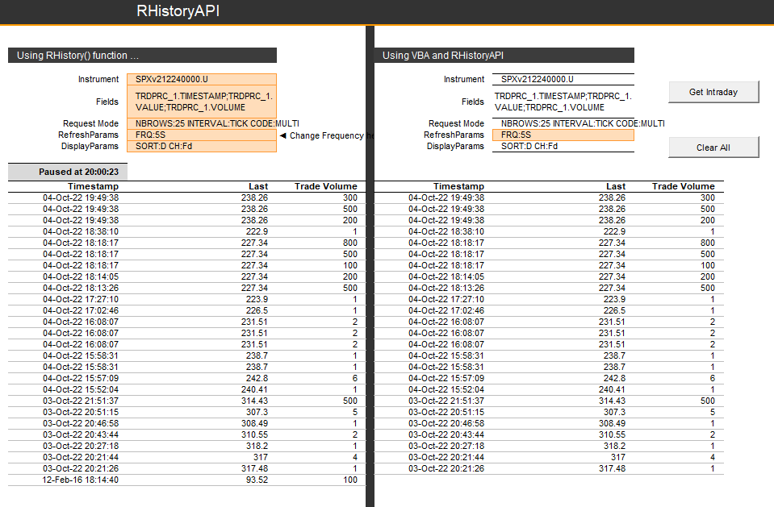

### Python

For this, we can (yet again) use the `get_history` function:

```python
IntradayTimeSeriesDf2 = rd.get_history(
    universe=FTSEConstituents,
    fields=['TRDPRC_1'],
    interval="10min", # The consolidation interval. Supported intervals are: tick, tas, taq, minute, 1min, 5min, 10min, 30min, 60min, hourly, 1h, daily, 1d, 1D, 7D, 7d, weekly, 1W, monthly, 1M, quarterly, 3M, 6M, yearly, 1Y.
    start="2022-06-01T13:00:00",
    end="2022-06-01T16:00:00")

IntradayTimeSeriesDf2
```

| TRDPRC_1 Timestamp | STAN.L | CRDA.L | ANTO.L | BNZL.L | SGE.L | SVT.L | BLND.L | ICAG.L | REL.L | SMIN.L | AZN.L | HSBA.L | CTEC.L | WPP.L | FRES.L | AAF.L | SGRO.L | SJP.L | TW.L | AHT.L | HLMA.L | III.L | CNA.L | MNG.L | BKGH.L | SMDS.L | NG.L | RKT.L | SKG.L | … |
| --- | --- | --- | --- | --- | --- | --- | --- | --- | --- | --- | --- | --- | --- | --- | --- | --- | --- | --- | --- | --- | --- | --- | --- | --- | --- | --- | --- | --- | --- | --- |
| 2022-06-01 13:00:00 | 637.6 | 6918 | 1509.5 | 2789 | 653.2 | 2856.0 | 526.8 | 128.86 | 2250.0 | 1572.0 | 10494 | 535.6 | 218.033 | 937.8 | 770.0 | 156.1 | 1094.0 | 1260.0 | 131.0 | 4125.0 | 2218.0 | 1252.5 | 80.06 | 218.1 | 4260 | 307.4 | 1128.0 | 6244 | 3234 | … |
| 2022-06-01 13:10:00 | 636.6 | 6936 | 1511.5 | 2807 | 654.4 | 2852.0 | 526.4 | 129.16 | 2257.0 | 1573.0 | 10504 | 534.0 | 218.6 | 938.4 | 770.2 | 155.9 | 1096.5 | 1259.5 | 130.9 | 4144.0 | 2223.8 | 1251.5 | 79.94 | 217.4 | 4255 | 308.2 | 1126.0 | 6238 | 3237 | … |
| 2022-06-01 13:20:00 | 636.0 | 6940 | 1511.5 | 2812 | 655.6 | 2855.65 | 526.0 | 129.02 | 2255.0 | 1574.0 | 10530 | 534.1 | 218.4 | 938.2 | 770.4 | 156.1 | 1098.5 | 1259.5 | 130.75 | 4140.6617 | 2225.0 | 1256.5 | 80.1 | 217.5 | 4248 | 307.6 | 1128.0 | 6252 | 3226 | … |
| 2022-06-01 13:30:00 | 635.2 | 6934 | 1513.0 | 2809 | 658.0 | 2854.0 | 524.6 | 128.54 | 2252.0 | 1574.5 | 10520 | 533.1 | 217.6 | 936.8 | 769.6 | 156.2 | 1097.0 | 1258.5 | 130.35 | 4145.0 | 2225.0 | 1252.0 | 80.04 | 217.8 | 4240 | 307.0 | 1127.5 | 6252 | 3227 | … |
| 2022-06-01 13:40:00 | 635.7 | 6936 | 1516.0 | 2810 | 658.0 | 2852.0 | 524.4 | 128.26 | 2251.0 | 1575.0 | 10516 | 533.5 | 218.0 | 935.8 | 770.4 | 155.4 | 1094.5 | 1259.5 | 130.25 | 4147.0 | 2224.0 | 1252.5 | 80.04 | 218.1 | 4237 | 306.7 | 1125.7 | 6244 | 3232 | … |
| 2022-06-01 13:50:00 | 635.4 | 6914 | 1511.5 | 2805 | 658.8 | 2852.0 | 524.2 | 128.36 | 2251.0 | 1573.0 | 10492 | 533.2 | 217.6 | 934.4 | 769.2 | 155.27 | 1094.5 | 1257.0 | 130.2 | 4135.0 | 2220.0 | 1253.5 | 80.0 | 217.45 | 4233 | 305.5 | 1124.5 | 6240 | 3233 | … |
| 2022-06-01 14:00:00 | 634.4 | 6870 | 1509.5 | 2797 | 656.4 | 2852.0 | 524.6 | 128.08 | 2242.0 | 1566.8 | 10450 | 532.6 | 216.6 | 930.6 | 764.8 | 155.2 | 1091.0 | 1250.5 | 129.9 | 4110.0 | 2213.0 | 1245.5 | 79.92 | 217.3 | 4230 | 305.0483 | 1123.9883 | 6230 | 3223 | … |
| 2022-06-01 14:10:00 | 634.2 | 6866 | 1505.5 | 2797 | 655.6 | 2845.0 | 523.0 | 127.5 | 2238.0 | 1565.0 | 10460 | 532.3 | 216.4 | 929.0 | 764.588 | 154.5 | 1090.5 | 1249.5 | 129.9 | 4097.0 | 2214.0 | 1244.3891 | 79.8992 | 217.5 | 4231 | 304.7 | 1123.06 | 6228 | 3211 | … |
| 2022-06-01 14:20:00 | 633.0 | 6852 | 1502.0415 | 2793 | 655.8 | 2848.0 | 525.2 | 127.04 | 2236.328 | 1563.5 | 10464 | 532.2 | 216.2 | 926.2 | 765.2 | 155.0 | 1090.0 | 1248.0 | 129.65 | 4078.0 | 2207.0 | 1241.5 | 79.92 | 217.3 | 4237 | 304.2 | 1122.8495 | 6230 | 3195 | … |
| 2022-06-01 14:30:00 | 632.8 | 6832 | 1496.5 | 2793 | 654.6 | 2854.6495 | 524.6 | 127.12 | 2232.0 | 1562.0 | 10448 | 531.6 | 215.8 | 927.0 | 763.8 | 154.672 | 1090.5 | 1246.5 | 129.8649 | 4071.0 | 2204.0 | 1240.0 | 79.6 | 216.475 | 4235 | 303.5 | 1124.0 | 6204 | 3192 | … |
| 2022-06-01 14:40:00 | 632.8 | 6822 | 1494.5 | 2783 | 654.4 | 2846.0 | 524.6 | 127.5 | 2223.0 | 1559.0 | 10426 | 531.3 | 215.2 | 928.0 | 763.4 | 154.3 | 1090.5 | 1247.0 | 129.85 | 4052.0 | 2202.0 | 1240.0 | 79.44 | 216.2 | 4234 | 303.6 | 1120.0 | 6200 | 3195 | … |
| 2022-06-01 14:50:00 | 633.4 | 6820 | 1501.5 | 2790 | 655.402 | 2849.0 | 524.2 | 127.52 | 2227.0 | 1562.0 | 10448 | 532.3 | 215.0 | 928.88 | 767.0 | 154.6143 | 1091.0 | 1251.0 | 130.05 | 4058.0 | 2202.0 | 1245.75 | 79.7 | 217.3 | 4239 | 304.5 | 1120.0 | 6190 | 3206 | … |
| 2022-06-01 15:00:00 | 632.0 | 6814 | 1495.5 | 2787 | 655.4 | 2842.65 | 522.4 | 127.12 | 2218.0 | 1561.0 | 10444 | 529.7 | 214.6 | 925.6 | 768.0 | 154.755 | 1086.0 | 1245.9601 | 129.9 | 4034.02 | 2194.0 | 1237.0 | 79.759 | 216.9 | 4239 | 303.3 | 1119.3495 | 6162 | 3185 | … |
| 2022-06-01 15:10:00 | 632.4 | 6796 | 1502.75 | 2786 | 653.6 | 2839.0 | 522.2 | 126.78 | 2210.0 | 1560.0 | 10450 | 529.69 | 214.2 | 923.4 | 770.4 | 154.6 | 1086.0 | 1244.49 | 129.8 | 4032.0 | 2190.0 | 1242.7495 | 79.94 | 216.7 | 4237 | 302.9 | 1118.0 | 6166 | 3179 | … |
| 2022-06-01 15:20:00 | 632.4 | 6782 | 1500.0 | 2793 | 652.4 | 2836.0 | 520.6 | 126.54 | 2206.0 | 1558.5 | 10424 | 528.4 | 214.0 | 923.8 | 768.4 | 154.0 | 1084.0 | 1242.0 | 129.65 | 4027.0 | 2188.0 | 1241.0 | 80.02 | 216.2 | 4238 | 302.3 | 1118.0 | 6172 | 3186 | … |
| 2022-06-01 15:30:00 | 632.8 | 6758 | 1495.0 | 2811 | 653.6 | 2833.0 | 521.2 | 125.92 | 2207.0 | 1561.0 | 10442 | 529.6 | 213.4 | 924.25366 | 769.0 | 153.9 | 1084.0 | 1247.5 | 129.75 | 4011.0 | 2181.0 | 1242.43 | 80.54 | 216.4 | 4238 | 303.2 | 1121.0 | 6180 | 3179 | … |
| 2022-06-01 15:40:00 | <NA> | <NA> | <NA> | <NA> | <NA> | <NA> | <NA> | <NA> | <NA> | <NA> | <NA> | <NA> | <NA> | <NA> | <NA> | <NA> | <NA> | <NA> | <NA> | <NA> | <NA> | <NA> | <NA> | <NA> | <NA> | <NA> | <NA> | <NA> | <NA> | … |
| 2022-06-01 15:50:00 | <NA> | <NA> | <NA> | <NA> | <NA> | <NA> | <NA> | <NA> | <NA> | <NA> | <NA> | <NA> | <NA> | <NA> | <NA> | <NA> | <NA> | <NA> | <NA> | <NA> | <NA> | <NA> | <NA> | <NA> | <NA> | <NA> | 1120.44 | <NA> | <NA> | … |

## PLSynchronization Manager

This synchronisation manager was an old method whereby the COM API managed connections to Refinitiv Datasets. It is no longer required in python.

## RSearch

RSearch is a COM API function for instrument level search - designed for building instrument lists conforming to various search criteria. See the example below:

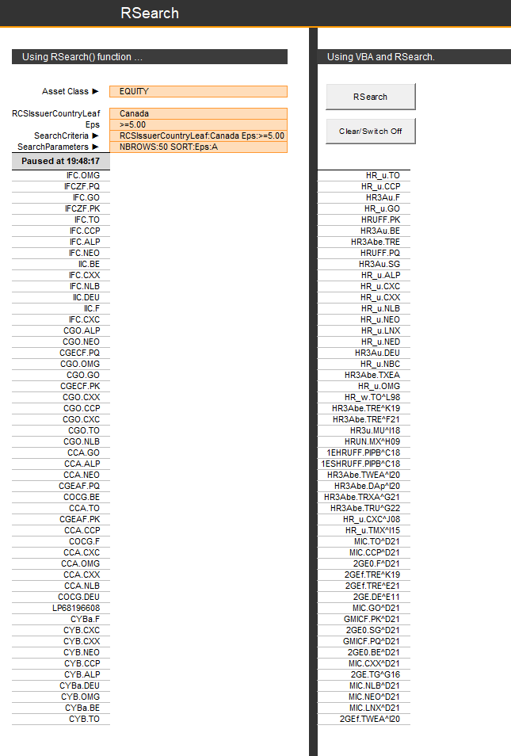

[RSearch is a powerful COM API function](https://my.refinitiv.com/content/mytr/en/policies/training-portal/videoarticle.v11535.html). It was best exemplified in [Tutorial 7 - Instrument Search - RSearch](https://developers.refinitiv.com/en/api-catalog/eikon/com-apis-for-use-in-microsoft-office/tutorials#tutorial-7-instrument-search-r-search)'s [Excel Workbook](https://developers.refinitiv.com/content/dam/devportal/api-families/eikon/com-apis-for-use-in-microsoft-office/tutorials/rsearch.zip).

### VBA

Creating the sub `cmdRSearch_Click`:

> ```
>     ' Instantiate the RSearch manager
>     Set myRSrchMgr = CreateRSearchMgr()
>
>     If Not myRSrchMgr Is Nothing Then
>         ' Initialize RSearch session (we do not provide any logger here)
>         ' NOTE - This will error if Eikon for Excel is not logged in.
>         myRSrchCookie = myRSrchMgr.Initialize(RS_CT_EIKON)
>         ' Create a RSearch query using the session cookie
>         Set myRSrchQry = myRSrchMgr.CreateRSearchQuery(myRSrchCookie)
>
>         If Not myRSrchMgr Is Nothing Then
>             With myRSrchQry
>                 'Initialize the RSearch query with the criteria to use for the search
>                 .AssetClass = [AssetClass].Value
>                 .SearchCriteria = [SearchCriteria].Value '"EPS:>5 RCSIssuerCountryLeaf:Canada"
>                 .SearchParameters = [SearchParameters].Value '"NBROWS:50 SORT:EPS:A"
>
>                 ' Send the query
>                 .Send
>             End With
>         End If
>     End If
> ```

Then you can check the status of the query with '`myRSrchQry_OnUpdate`'.

### Python

[RSearch is a powerful COM API function](https://my.refinitiv.com/content/mytr/en/policies/training-portal/videoarticle.v11535.html), and we're happy to announce that the Python equivalent - Search API - is even more powerful. For the full works on it, please do read Nick Zicone's article '[Building Search into your Application Workflow](https://developers.refinitiv.com/en/article-catalog/article/building-search-into-your-application-workflow)'.

```python
bondsSerarch = search.Definition(
    view=search.Views.BOND_FUT_OPT_QUOTES,  # for info on `SearchViews`, you can use `help(search.Views)`
    # specify filtering properties
    filter="IssueCouponRate ge 2",
    # select only the required fields
    select='CommonName, IssuerCommonName, IssueCouponRate, Currency, IssuerCountryName',
    # then specify number of items to be 10000, which is the max; default value is 100
    top=10000
).get_data().data.df

bondsSerarch.head()
```

|  | CommonName | IssuerCommonName | IssueCouponRate | Currency | IssuerCountryName |
| --- | --- | --- | --- | --- | --- |
| 0 | TTN 2.375 11/16/24 '24 | Titan Global Finance PLC | 2.375 | EUR | United Kingdom |
| 1 | BNP 4.000 10/21/23 | Banca Nazionale del Lavoro SpA | 4.0 | EUR | Italy |

```python
equitySerarch = search.Definition(
    view=search.Views.EQUITY_QUOTES,  # for info on `SearchViews`, you can use `help(search.Views)`
    filter="MktCapCompanyUsd ge 1000000000000",
    # select only the required fields
    select='CommonName, PriceCloseUsd, MktCapCompanyUsd',
    # then specify number of items to be 10000, which is the max; default value is 100
    top=100
).get_data().data.df

equitySerarch.head()
```

|  | CommonName | PriceCloseUsd | MktCapCompanyUsd |
| --- | --- | --- | --- |
| 0 | APPLE ORD | 151.03 | 2389588504380 |
| 1 | MICROSOFT ORD | 255.29 | 1900328603939 |
| 2 | ALPHABET CL A ORD | 93.65 | 1201583710000 |
| 3 | SAUDI ARABIAN OIL ORD | 8.526739 | 1875882650750 |
| 4 | ALPHABET CL C ORD | 94.02 | 1201583710000 |

```python
MnA = search.Definition(
    view=search.Views.DEALS_MERGERS_AND_ACQUISITIONS,  # for info on `SearchViews`, you can use `help(search.Views)`

    # specify filtering properties
    filter="((AcquirerCompanyName ne 'Creditors' and AcquirerCompanyName ne 'Shareholder') and (TargetCountry eq 'US' or TargetCountry eq 'UK')"
    + "and TransactionValueIncludingNetDebtOfTarget ge 100 and TargetPublicStatus eq 'Public')"
    + "and (TransactionStatus eq 'Completed' or TransactionStatus eq 'Pending' or TransactionStatus eq 'Withdrawn')"
    + "and (FormOfTransactionName xeq 'Merger' or FormOfTransactionName xeq 'Acquisition') and (TransactionAnnouncementDate le 2021-11-15 and TransactionAnnouncementDate ge 2020-09-15)",

    # select only the required fields and order them based on announcement date
    # then specify number of items to be 10000, which is the max; default value is 100
    select='TransactionAnnouncementDate, TargetCompanyName, TargetRIC',
    order_by='TransactionAnnouncementDate desc',
    top=10000
).get_data()
MnA = MnA.data.df

#remove companies which doesn't have RIC
MnA = MnA.dropna(subset = ['TargetRIC']).reset_index(drop = True)

print(f'Number of M&A deals for the specified period is {len(MnA)}')
MnA.head()
```

```
Number of M&A deals for the specified period is 326
```

|  | TransactionAnnouncementDate | TargetCompanyName | TargetRIC |
| --- | --- | --- | --- |
| 0 | 2021-11-15 | CyrusOne Inc | [CONE.O^C22] |
| 1 | 2021-11-15 | CoreSite Realty Corp | [COR^L21] |
| 2 | 2021-11-15 | LAACO Ltd | [LAACZ.PK^L21] |
| 3 | 2021-11-15 | Casper Sleep Inc | [CSPR.K^A22] |
| 4 | 2021-11-08 | McAfee Corp | [MCFE.O^C22] |

A more complex method may be to create a function that incorporates that search function, outputing an excel file. [This](https://gist.github.com/johnukfr/241c2b360a30f96371f430005c8d7738) is a real-life use case replicating RSearch functionality's in looking for Government and Corporate Debt Instruments; the function is rather large, so we put it online for you to access.

The RD Library has also added a number of ease-of-use features as the Search API is very comprehensive - but with that comes some complexity. Search Templates is one such useful feature.

#### Search templates are defined using the following JSON structure

- **description** (string): Description of the template.
- **parameters** (object): Parameters of the template. These parameters can be used as placeholders in the request_body of the template and as named parameters of the search() method of the template. Each parameter has a name, a description, and an optional default value.
- **request_body** (object): Body of the request sent to the Search REST API. This request body can include template parameters surrounded by '#{' and '}' (for example: “#{my_param}”). More details on the structure of the request body can be found in the [Search API reference guide](https://apidocs.refinitiv.com/Apps/ApiDocs#/details/L2Rpc2NvdmVyeS9zZWFyY2gvdjE=/Lw==/POST/README) (access to this guide requires a Refinitiv Workspace account or RDP account to log in).

##### Template example

```
"MyTemplate": {
    "description": "Search template example.",
    "parameters": {
        "name": {
            "description": "Name of the person to search for.",
            "default": "Edison"
        }
    },
    "request_body": {
       "Query": "#{name}",
       "View":"People",
       "Top":10
    }
}
```

**Example of usage**

```
rd.discovery.search_templates["MyTemplate"].search(name="Pasteur")
```

```python
from physical_assets_map import PhysicalAssetsMap
```

```python
#some imports to start with
from physical_assets_map import PhysicalAssetsMap
```

```python
#load the search templates configuration file
rd.load_config("search-templates.config.json")
```

```
<ConfigurationSet: 0x7fe91a3c3908>
```

##### Mine Search Template example

```python
mines = rd.discovery.search_templates["Mines"]
```

##### Get help about this template

```python
help(mines)
```

```
Help on DiscoverySearchTemplate in module refinitiv.data.discovery._search_templates.search object:

class DiscoverySearchTemplate(refinitiv.data.discovery._search_templates.base.TargetTemplate)
 |  DiscoverySearchTemplate(name=None, *, placeholders_defaults: Union[Dict[str, Any], NoneType] = None, pass_through_defaults: Union[Dict[str, Any], NoneType] = None, optional_placeholders: Iterable[str] = None, ns: 'Namespace' = None, **search_defaults)
 |  Discovery search preset class
 |  Method resolution order:
 |      DiscoverySearchTemplate
 |      refinitiv.data.discovery._search_templates.base.TargetTemplate
 |      builtins.object
 |  Methods defined here:
 |  __repr__(self)
 |      Return repr(self).
 |  search(self, **kwargs) -> pandas.core.frame.DataFrame
 |      Please, use help() on a template object itself to get method documentation
 |  ----------------------------------------------------------------------
 |  Methods inherited from refinitiv.data.discovery._search_templates.base.TargetTemplate:
 |  __init__(self, name=None, *, placeholders_defaults: Union[Dict[str, Any], NoneType] = None, pass_through_defaults: Union[Dict[str, Any], NoneType] = None, optional_placeholders: Iterable[str] = None, ns: 'Namespace' = None, **search_defaults)
 |      Parameters
 |      ----------
 |      name : str, optional
 |          name of the template
 |      placeholders_defaults: dict, optional
 |          Dict of string template placeholders default values.
 |      pass_through_defaults: dict, optional
 |          default values for the Target parameters
 |      optional_placeholders: Iterable[str], optional
 |          names of placeholders that are optional without default values
 |      ns: Namespace
 |          Namespace in which template will operate. Used for subtemplates.
 |  ----------------------------------------------------------------------
 |  Data descriptors inherited from refinitiv.data.discovery._search_templates.base.TargetTemplate:
 |  __dict__
 |      dictionary for instance variables (if defined)
 |  __weakref__
 |      list of weak references to the object (if defined)
```

##### Use the predefined parameters of the template to search for gold mines in south Africa

```python
from ipyleaflet import Map
mines_coordinates = mines.search(commodity="Gold", region="South Africa")

PhysicalAssetsMap().plot(mines_coordinates).show()
display(mines_coordinates)
```

```
Map(center=[-26.416700363159, 27.666700363159], controls=(ZoomControl(options=['position', 'zoom_in_text', 'zo…
```

|  | RIC | RCSRegionLeaf | RCSCommodityTypeLeaf | DTSubjectName | PhysicalAssetStatus | Latitude | Longitude |
| --- | --- | --- | --- | --- | --- | --- | --- |
| 0 | C}PX7309413492 | South Africa | Gold | South Deep | Normal Operation | -26.4167 | 27.6667 |
| 1 | C}PX7309413493 | South Africa | Gold | Target | Normal Operation | -27.76 | 26.629999 |
| 2 | C}PX7309413494 | South Africa | Gold | Tshepong | Normal Operation | -27.866699 | 26.6833 |
| 3 | C}PX7309413495 | South Africa | Gold | Tau Lekoa | Normal Operation | -27.0 | 26.613001 |
| 4 | C}PX7309413496 | South Africa | Gold | Kopanang | Normal Operation | -26.98 | 26.745001 |
| ... | ... | ... | ... | ... | ... | ... | ... |
| 88 | C}PX7310050444 | South Africa | Gold | Bloemhoek | Feasibility | -27.534979 | 27.196499 |
| 89 | C}PX7310050445 | South Africa | Gold | De Bron Merriespruit | Feasibility | -27.571728 | 27.19503 |
| 90 | C}PX7310050461 | South Africa | Gold | Moab MOD | Normal Operation | -26.989622 | 26.802376 |
| 91 | C}PX7310054031 | South Africa | Gold | Far West Gold Recoveries (FWGR) | Normal Operation | -26.389465 | 27.360319 |
| 92 | C}PX7310101973 | South Africa | Gold | Mine Waste Solutions | Normal Operation | -26.8417 | 26.866699 |

93 rows × 7 columns

## News

### Streaming News

The Office COM API allowed for streaming real time news. This was rather inconvenient because one would have to (i) record news flowing through on their own environment, (ii) be recording with an open streaming session when the news they're looking for is published, (iii) deal with the memory management involved with such streaming data. The Python code below recreated this, but takes a snapshot at the time the code is run:

(N.B: The Accessing News data with the RD or EDAPI Python libraries will only allow you access to news data up to three months ago. For news data predating that, look into [this article](https://developers.refinitiv.com/en/article-catalog/article/news-sentiments---gleaning-insights).)

```python
#Define Callback for stream
def display_data(data, instrument, stream):
    clear_output(wait=True)
    current_time = datetime.datetime.now().time()
    print(current_time, "- Data received for", instrument)
    display(data)
```

```python
# This will trigger the stream:
stream = rd.open_pricing_stream(
    universe=['NFCP_UBMS'],
    on_data=display_data)
```

```
11:21:11.353212 - Data received for NFCP_UBMS
```

|  | NEWSCODE18 | PNAC | SEQ_NO | TAKE_SEQNO | NEWSCODE20 | SYS_DUPID | AREA_ID | ATTRIBTN | PRODCODE_N | PROD_PERM | NEWSCODE13 | PROC_DATE | NEWSCODE11 | SRCOFDATA | NEWS_PRIO | STORY_TYPE | CROSS_REF | STORY_DATE | NEWSCODE15 | RECORDTYPE | DSPLY_NAME | SF_NAME | HEADLINE1 | NEWSCODE01 | NEWSCODE02 | NEWSCODE03 | NEWSCODE04 | NEWSCODE05 | NEWSCODE06 | … |
| --- | --- | --- | --- | --- | --- | --- | --- | --- | --- | --- | --- | --- | --- | --- | --- | --- | --- | --- | --- | --- | --- | --- | --- | --- | --- | --- | --- | --- | --- | --- |
| NFCP_UBMS | None | nBER3DRDqJ | 543729 | 1 | None | news_bma | 3 | BER | BER | 457 | None | 2023-03-06 | None | 3 | 3 | S | None | 2023-03-06 | None | 232 | 30 | bma | CRUDE PALM OIL FUTURES CLOSING: MARCH 6 | A:4 G:1 G:2EK G:8S G:CI G:K G:S M:1QD M:2CM M:... | None | None | None | None | None | … |

```python
stream.close()
```

```
<OpenState.Closed: 'Closed'>
```

#### Selecting Only a Subset of Fields

Above we are dumping all the fields - you may only be interested in a subset of fields - if so you can manage as below:

```python
stream = rd.open_pricing_stream(
    universe=['NFCP_UBMS'],
    fields=['PNAC','HEADLINE1'],
    on_data=display_data)
```

```
11:21:21.862759 - Data received for NFCP_UBMS
```

|  | PNAC | HEADLINE1 |
| --- | --- | --- |
| NFCP_UBMS | nNSEsrY7f | APOLLOTYRE-Loss of Share Certificates |

```python
stream.close()
```

```
<OpenState.Closed: 'Closed'>
```

#### NEW FUNCTIONALITY: Get News headlines

We added this functionality to find the headlines of news which was not a functionality in the old COM API:

```python
newsResponse = rd.news.get_headlines(query='LSEG',start="20.03.2022",end="25.03.2022",count=3)
newsResponse
```

| versionCreated | headline | storyId | sourceCode |
| --- | --- | --- | --- |
| 2022-03-24 18:27:20.000 | BRIEF-London Stock Exchange Secondary ABO Book... | urn:newsml:newswire.refinitiv.com:20220324:nFW... | NS:RTRS |
| 2022-03-24 18:09:06.000 | BRIEF-London Stock Exchange Secondary ABO Book... | urn:newsml:newswire.refinitiv.com:20220324:nFW... | NS:RTRS |
| 2022-03-24 17:56:21.654 | BLOCKTRADE: LONDON STOCK EXCHANGE SECONDARY A... | urn:newsml:newswire.refinitiv.com:20220324:nFW... | NS:RTRS |

### Historical News

```python
story_id = newsResponse.iat[1,1]
story_id
```

```
'urn:newsml:newswire.refinitiv.com:20220324:nFWN2VR17K:1'
```

```python
from IPython.display import HTML
story = rd.news.get_story(story_id)
HTML(story)
```

March 24 (Reuters) - London Stock Exchange Group Secondary ABO Bookrunner:

- BLOCKTRADE: LONDON STOCK EXCHANGE SECONDARY ABO: DEAL EXPECTED TO PRICE AT £77.00 PER SHARE; BOOKS MULTIPLE TIMES COVERED AT THAT LEVEL - BOOKRUNNER

- BLOCKTRADE: LONDON STOCK EXCHANGE SECONDARY ABO: BOOKS WILL CLOSE AT 18:15 UK / 19:15 CET - BOOKRUNNER

Further company coverage: LSEG.L

(( Reuters.Briefs@thomsonreuters.com ;))

(c) Copyright Thomson Reuters 2022. Click For Restrictions - https://agency.reuters.com/en/copyright.html

## Contribution - AdxRtContribute.dll

**CONTRIBUTIONS WORKFLOW IN PYTHON IS UPCOMING.** Keep an eye on this article, it will be updates with such Python use-cases.

### What does AdxRtContribute.dll do?

#### VBA

AdxRtContribute is for data contribution either locally (SCOPE:LOCAL) within the instance of Excel (or application if EikonDesktopDataAPI has been used) or on to a server (SCOPE:SERVER) and potentially on to IDN (where the Source Alias of "TRC" should be specified).

AdxRtContribute replicates the RtContribute() function in Eikon for Excel or Eikon - Microsoft Office.

NOTE - Eikon for Excel or Eikon - Microsoft Office should be logged in otherwise the sample VBA code will generate an error "ERROR #360c - AdxRtx : No connection to the platform".

**Prerequisites**

```
1. Open a new single sheet Excel workbook.
   Save As with an appropriate name (e.g. AdxRtContribute.xls or AdxRtContribute.xlsm in Office 2007 or higher).

2. Go to the VBE (Visual Basic Editor), ensure the Project Explorer is visible and select the project for the workbook above.
   <ALT><F11> or Tools, Macro, Visual Basic Editor in Excel 2003 or  Developer, Visual Basic in Excel 2007 and above, View, Project Explorer If the Developer header is not visible in Excel 2007 and above, go to the Excel Office Button, select Excel Options (lower right), Popular, and check the 'Show Developer tab in the Ribbon' box.
3. In the VBE, click on File, Import File and import PLVbaApis.bas.
   The .bas location is C:\Program Files (x86)\Thomson Reuters\Eikon\Z\Bin (Z may be X or Y, depending on the last Eikon update). The .bas is loaded as a new VB project module, PLVbaApis.
4. In the PLVbaAPis module, comment out the sections which aren't required.
   As this example is dealing with AdxRtContribute, part of the real time library AdfinXRtLib, the AdfinX Real Time section can remain uncommented.
5. In the VBE, go Tools, References and ensure that AdfinX Real Time Library is checked.
   If it is not in the list the library is called rtx.dll and its location for Eikon 4 is >C:\Program Files (x86)\Thomson Reuters\Eikon\Z\Bin (Z may be X or Y, depending on the last Eikon update).
AdxRtContribute
```

```
6. Create an instance of an AdxRtContribute object using the PLVbaApis function CreateAdxRtContribute.
```

> Set myAdxRtContrib = CreateAdxRtContribute

```
7. To replicate RtContribute(), when the object has been created set the source, item name and mode (if required) and then contribute the field(s) and value(s) desired.
```

> ```
> Public myAdxRtContrib As AdfinXRtLib.AdxRtContribute
>
> Dim fields (1 To 3) As Variant
> Dim values (1 To 3) As Variant
>
> Sub myContribution()
>   Set myAdxRtContrib = CreateAdxRtContribute
>   If myAdxRtContrib Is Nothing Then MsgBox "Failed to create RtContribute"
>     With myAdxRtContrib
>       .Source = "DAVID2"
>       .ItemName = "TEST_RIC2"
>       .Mode = "SCOPE:LOCAL UPDATE:CHANGED"
>
>       fields (1)="BID"
>       fields (2)="ASK"
>       fields (3)="ASKROW80_1"
>       values(1)=210
>       values(2)=220
>       values(3)="ABCDEF"
>
>       .Contribute fields, values
>       '.Contribute "ASK", 220 ' Alternative method of actual names and values'
>       '.Contribute Array("BID", "ASK"), Array(210, 220) ' Another alternative method'
>    End With
> End Sub
> ```

```
8. RtGet() or RData() can be used in Eikon for Excel to check that the contribution has been successful. If the AdxRtList COM API for real time data retrieval is being used this can be set with the appropriate source and instrument parameters.

9. If no more contributions are required the AdxRtContribute object can be closed (set to Nothing).
```

#### Python

**CONTRIBUTIONS WORKFLOW IN PYTHON IS UPCOMING.** Keep an eye on this article, it will be updates with such Python use-cases.

## Conclusion

In conclusion, we can see that the [Office COM API](https://developers.refinitiv.com/en/api-catalog/eikon/com-apis-for-use-in-microsoft-office) had many great uses, but limitations too. This was without mentioning its reliability on [DLL](https://docs.microsoft.com/en-us/troubleshoot/windows-client/deployment/dynamic-link-library)s that can be heavy to run on a personal machine. But the Refinitiv Python Libraries ([RD](https://developers.refinitiv.com/en/api-catalog/refinitiv-data-platform/refinitiv-data-library-for-python), [RDP](https://developers.refinitiv.com/en/api-catalog/refinitiv-data-platform/refinitiv-data-platform-apis) and [EDAPI](https://developers.refinitiv.com/en/api-catalog/eikon/eikon-data-api)) can not only replicate these COM functionalities but enhance them in many instances, the simplest example being the Historical News functionality shown above.

Several COM API functionalities relying on a technology called Adfin was not replicated in Python in this article, but we will investigate them in another article - so stay tuned!

# Further Information

## COM Prerequisites

1. Open a new single sheet Excel workbook.

   Save As with an appropriate name (e.g. AdxRtSourceList.xls or AdxRtSourceList.xlsm in Office 2007 or higher).
2. Go to the VBE (Visual Basic Editor), ensure the Project Explorer is visible and select the project for the workbook.

   \<ALT>\<F11> or Tools, Macro, Visual Basic Editor in Excel 2003 or Developer, Visual Basic in Excel 2007 and above, View, Project Explorer If the Developer header is not visible in Excel 2007 and above, go to the Excel Office Button, select Excel Options (lower right), Popular, and check the 'Show Developer tab in the Ribbon' box.
3. In the VBE, click on File, Import File and import PLVbaApis.bas.

   The .bas location is C:\Program Files (x86)\Thomson Reuters\Eikon\Z\Bin (Z may be X or Y, depending on the last Eikon update). The .bas is loaded as a new VB project module, PLVbaApis.
4. In the PLVbaAPis module, comment out the sections which aren't required.

   E.G.: when dealing with AdxRtSourceList, part of the real time library AdfinXRtLib, the AdfinX Real Time section can remain uncommented.
5. In the VBE, go Tools, References and ensure that AdfinX Real Time Library is checked.

   If it is not in the list the library is called rtx.dll and its location for Eikon 4 is ">C:\Program Files (x86)\Thomson Reuters\Eikon\Z\Bin (Z may be X or Y, depending on the last Eikon update).

## Further Resources

COM APIs: [Overview](https://developers.refinitiv.com/en/api-catalog/eikon/com-apis-for-use-in-microsoft-office) | [Quickstart Guide](https://developers.refinitiv.com/en/api-catalog/eikon/com-apis-for-use-in-microsoft-office/quick-start) | [Documentation](https://developers.refinitiv.com/en/api-catalog/eikon/com-apis-for-use-in-microsoft-office/documentation) | [Downloads](https://developers.refinitiv.com/en/api-catalog/eikon/com-apis-for-use-in-microsoft-office/download) | [Tutorials](https://developers.refinitiv.com/en/api-catalog/eikon/com-apis-for-use-in-microsoft-office/tutorials) | [Q&A Forum](https://community.developers.refinitiv.com/index.html?_ga=2.221580381.456015790.1678102215-1923062744.1661858778)

RD Library: [Overview](https://developers.refinitiv.com/en/api-catalog/refinitiv-data-platform/refinitiv-data-library-for-python) | [Quickstart Guide](https://developers.refinitiv.com/en/api-catalog/refinitiv-data-platform/refinitiv-data-library-for-python/quick-start) | [Documentation](https://developers.refinitiv.com/en/api-catalog/refinitiv-data-platform/refinitiv-data-library-for-python/documentation) | [Tutorials](https://developers.refinitiv.com/en/api-catalog/refinitiv-data-platform/refinitiv-data-library-for-python/tutorials) | [Q&A Forum](https://community.developers.refinitiv.com/spaces/321/index.html?_ga=2.149760115.456015790.1678102215-1923062744.1661858778)